# Milestone 1

## Setting Up

For this milestone, you will: solidify a dataset to use, come up with potential research questions, and run a correlation. For this key, I will use the `palmerpenguins` dataset to complete the exercises. My advice to you: make sure you complete lab 7 before completing this milestone 1. The assignments build off of one another and it makes most sense to complete the lab first.

### Libraries

```r
library(tidyverse)
library(ggplot2)
library(psych)
library(viridis)
library(palmerpenguins)
```

### Data: Pick a dataset

On Canvas, there is a folder with available datasets to pick for the final project. Spend some time going through them and select one that you want to work on this semester.

### EXERCISE 1: State Your Data

What dataset will you be using for the final project?

I will be using the `palmerpenguins` dataset for my final project.

### EXERCISE 2: Explain the Data

In a few sentences, explain what the dataset is all about.

This data is all about penguins!

### EXERCISE 3: Explain Why this Data

In a few sentences, explain what drew you to this dataset and why you are interested in using it for your final project.

I love animals and I thought it would be fun to explore relationships of different aspects of penguins.

In the code chunk below, load in your .csv dataset. Then, use `glimpse()` to take a peek.

```r
alcohol <- read.csv("student_alcohol_consumption.csv", stringsAsFactors = TRUE)
glimpse(alcohol)
```

```
## Rows: 39
## Columns: 37
## $ X          <int> 1, 2, 3, 4, 5, 6, 7, 8, 9, 10, 11, 12, 13, 14, 15, 16, 17, …
## $ school     <fct> GP, GP, GP, GP, GP, GP, GP, GP, GP, GP, GP, GP, GP, GP, GP,…
## $ sex        <fct> F, F, F, F, F, F, F, F, F, F, F, F, F, F, F, M, M, M, M, M,…
## $ age        <int> 15, 15, 15, 15, 15, 16, 16, 16, 17, 17, 17, 17, 17, 18, 18,…
## $ address    <fct> U, U, U, U, U, U, U, U, R, U, U, U, U, R, U, R, U, U, U, U,…
## $ famsize    <fct> GT3, GT3, GT3, LE3, LE3, GT3, LE3, LE3, GT3, GT3, GT3, GT3,…
## $ Pstatus    <fct> A, T, T, A, T, T, T, T, T, T, T, T, T, T, T, T, A, T, T, T,…
## $ Medu       <int> 3, 1, 4, 3, 4, 4, 2, 4, 2, 1, 2, 4, 0, 1, 2, 4, 2, 2, 4, 4,…
## $ Fedu       <int> 3, 1, 2, 4, 3, 3, 2, 3, 1, 1, 4, 4, 2, 1, 2, 3, 2, 2, 2, 3,…
## $ Mjob       <fct> other, other, other, other, services, health, other, teache…
## $ Fjob       <fct> health, other, other, other, services, other, at_home, serv…
## $ reason     <fct> reputation, home, reputation, home, reputation, home, cours…
## $ guardian   <fct> father, father, mother, mother, father, mother, father, mot…
```

[output cut: 24 more lines]

```r
glimpse(penguins)
```

```
## Rows: 344
## Columns: 8
## $ species           <fct> Adelie, Adelie, Adelie, Adelie, Adelie, Adelie, Adel…
## $ island            <fct> Torgersen, Torgersen, Torgersen, Torgersen, Torgerse…
## $ bill_length_mm    <dbl> 39.1, 39.5, 40.3, NA, 36.7, 39.3, 38.9, 39.2, 34.1, …
## $ bill_depth_mm     <dbl> 18.7, 17.4, 18.0, NA, 19.3, 20.6, 17.8, 19.6, 18.1, …
## $ flipper_length_mm <int> 181, 186, 195, NA, 193, 190, 181, 195, 193, 190, 186…
## $ body_mass_g       <int> 3750, 3800, 3250, NA, 3450, 3650, 3625, 4675, 3475, …
## $ sex               <fct> male, female, female, NA, female, male, female, male…
## $ year              <int> 2007, 2007, 2007, 2007, 2007, 2007, 2007, 2007, 2007…
```

## Research Questions

### EXERCISE 4: Develop Potential Research Questions

For the final project you will run 4 analyses: a correlation, a t-test, and 2 different multiple regressions. So far, we have only covered correlations. However, for this exercise your task is to come up with 4 research questions that you could address by looking at the data. Make sure you specify the independent and dependent variables/

**Correlation Research Question:** Come up with a correlation research question. As a reminder, a correlation looks at the relationship between two numeric variables. What are two numeric variables that you think could be related? In what way would they be related?

**Question:** Are bill length and bill depth positively related? Both are independent variables.

**T-Test Research Question:** Come up with a t-test research question. A t-test compares two different groups on a numeric variables. For example, I could look at if there is a difference in male versus female penguins (independent variable) on how much they weigh (dependent variable). My research question would be: Do male penguins weigh more than female penguins? T-Tests can **only** compare two different groups (not 3+).

**Question:** Do male penguins weigh more than female penguins? Penguin sex is the independent variable. Penguin weight is the dependent variable.

**Multiple Regression Research Questions:** Come up with two different multiple regression research questions. A regression as a numeric variable as a dependent variable. A Multiple regression is a regression that has 2 or more independent variables. I suggest sticking only to 2 or three independent variables. For example, I could look at if penguin species (independent variable 1) and penguin island (independent variable 2) impact penguin body mass (dependent variable).

**Question 1:** Do penguin species (independent variable 1) and penguin island (independent variable 2) impact penguin body mass (dependent variable)?

**Question 2:** Do penguin species (independent variable 1) and penguin island (independent variable 2) impact penguin flipper length (dependent variable)?

## Descriptive Statistics

### EXERCISE 5: Explore your Variables

In exercise 4, you identified all of your variables for the final project within the research questions.

**Numeric Variables:** For your numeric variables, use the `describe()` function from the `psych` library.

**Categorical Variables:** For your categorical variables, use the `table()` function to get a frequency table.

```r
#bill length and bill depth
#Penguin sex is the independent variable. Penguin weight is the dependent variable.
#Do penguin species (independent variable 1) and penguin island (independent variable 2) impact penguin body mass (dependent variable)?
#Do penguin species (independent variable 1) and penguin island (independent variable 2) impact penguin flipper length (dependent variable)?
```

Numeric Variables

```r
describe(penguins$bill_length_mm)
```

```
##    vars   n  mean   sd median trimmed  mad  min  max range skew kurtosis  se
## X1    1 342 43.92 5.46  44.45   43.91 7.04 32.1 59.6  27.5 0.05    -0.89 0.3
```

```r
describe(penguins$bill_depth_mm)
```

```
##    vars   n  mean   sd median trimmed  mad  min  max range  skew kurtosis   se
## X1    1 342 17.15 1.97   17.3   17.17 2.22 13.1 21.5   8.4 -0.14    -0.92 0.11
```

```r
describe(penguins$body_mass_g)
```

```
##    vars   n    mean     sd median trimmed    mad  min  max range skew kurtosis
## X1    1 342 4201.75 801.95   4050 4154.01 889.56 2700 6300  3600 0.47    -0.74
##       se
## X1 43.36
```

```r
describe(penguins$flipper_length_mm)
```

```
##    vars   n   mean    sd median trimmed   mad min max range skew kurtosis   se
## X1    1 342 200.92 14.06    197  200.34 16.31 172 231    59 0.34       -1 0.76
```

Categorical Variables

```r
table(penguins$sex)
```

```
##
## female   male
##    165    168
```

```r
table(penguins$species)
```

```
##
##    Adelie Chinstrap    Gentoo
##       152        68       124
```

```r
table(penguins$island)
```

```
##
##    Biscoe     Dream Torgersen
##       168       124        52
```

## Graphing

### EXERCISE 6: Create 2 visualizations

For this exercise you are tasked with picking two of your research questions from exercise 4 and create a graph for each of them. Make sure to add a theme, clean up the labels, and add a title.

Correlation plot

**Question:** Are bill length and bill depth positively related? Both are independent variables.

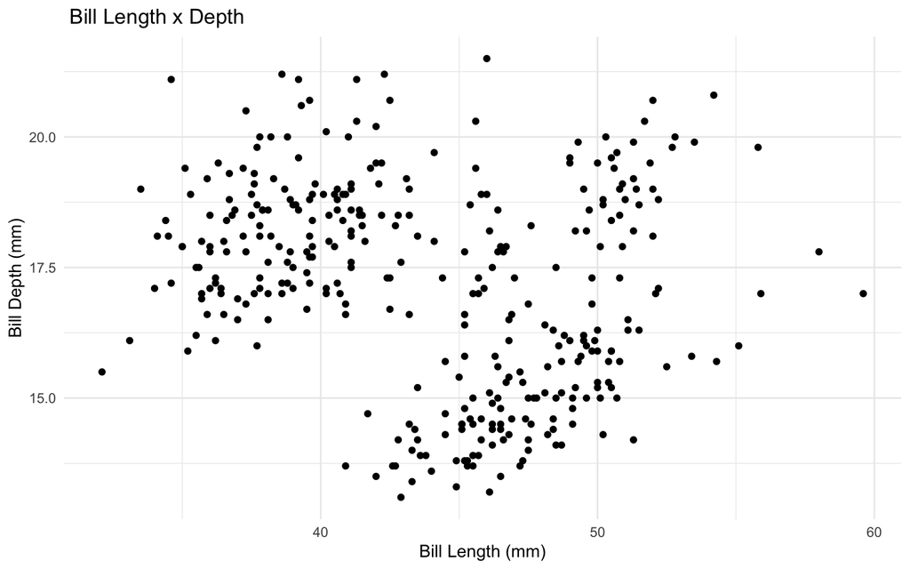

```r
ggplot(penguins, aes(bill_length_mm, bill_depth_mm)) +
  geom_point() +
  theme_minimal() +
  labs(x = "Bill Length (mm)", y = "Bill Depth (mm)",
       title = " Bill Length x Depth")
```

T-Test

**Question:** Do male penguins weigh more than female penguins? Penguin sex is the independent variable. Penguin weight is the dependent variable.

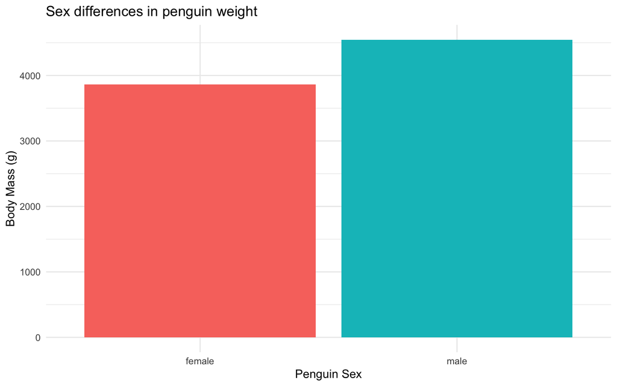

```r
ggplot(penguins %>% filter(!is.na(sex)), aes(sex, body_mass_g, fill = sex)) +
  stat_summary(fun = "mean", geom = "bar", position = "dodge") +
  theme_minimal() +
  labs(x = "Penguin Sex", y = "Body Mass (g)", title = "Sex differences in penguin weight") +
  guides(fill = "none")
```

**Question 1:** Do penguin species (independent variable 1) and penguin island (independent variable 2) impact penguin body mass (dependent variable)?

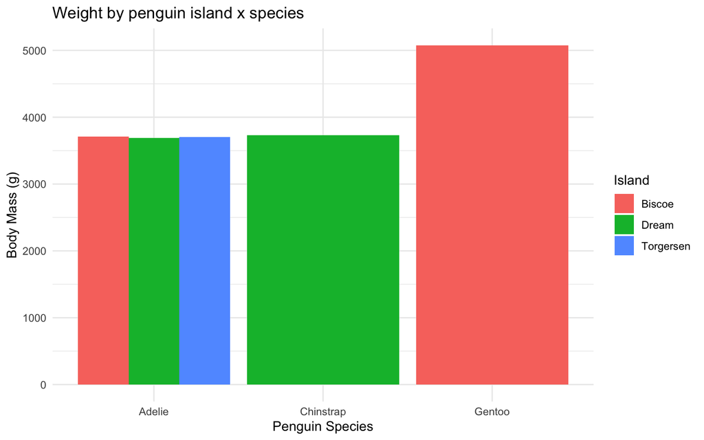

```r
ggplot(penguins, aes(species, body_mass_g, fill = island)) +
  stat_summary(fun = "mean", geom = "bar", position = "dodge") +
  theme_minimal() +
  labs(x = "Penguin Species", y = "Body Mass (g)", title = "Weight by penguin island x species", fill = "Island")
```

**Question 2:** Do penguin species (independent variable 1) and penguin island (independent variable 2) impact penguin flipper length (dependent variable)?

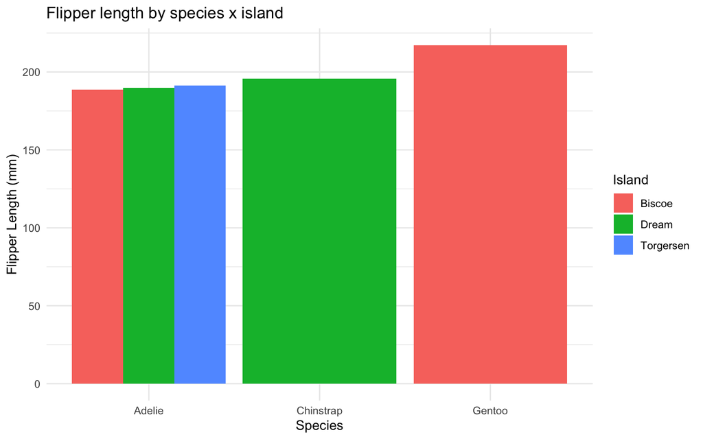

```r
ggplot(penguins, aes(species, flipper_length_mm, fill = island)) +
  stat_summary(fun = "mean", geom = "bar", position = "dodge") +
  theme_minimal() +
  labs(x = "Species", y = "Flipper Length (mm)", fill = "Island", title = "Flipper length by species x island")
```

### EXERCISE 7: Visualization Interpretation

In the space below, write several sentences interpreting what you learned from the two graphs you made in exercise 6.

## Correlation

### EXERCISE 8: Run Your Correlation

For this exercise you are tasked with running your correlation (using `cor.test()`) for the final project. After you run the correlation, interpret the results in APA format.

**Question:** Are bill length and bill depth positively related? Both are independent variables.

```r
cor.test(penguins$bill_length_mm, penguins$bill_depth_mm)
```

```
##
##  Pearson's product-moment correlation
##
## data:  penguins$bill_length_mm and penguins$bill_depth_mm
## t = -4.4591, df = 340, p-value = 1.12e-05
## alternative hypothesis: true correlation is not equal to 0
## 95 percent confidence interval:
##  -0.3328072 -0.1323004
## sample estimates:
##        cor
## -0.2350529
```

Interpretation:

There is a significant negative correlation between the bill length anf bill depth of a penguin, r(340) = -0.24, p < 0.01